# Data Prepation, Visualisation and Statistics

## Determining the Schengen Area

The first step for all data sets is to determine which values relate to countries afforded free movement across the German border and which do not.

As the Schengen Area was implemented in Germany on 26 March 1995, and no data used preceeds this data, all citizens of all EU member states have the right of free movement across the German border regardless of if their respective country has implemented the Schengen area. As such, the Schengen Area status was determined using the Schengen area member list, the membership start date for EU states, and implementation date for non-EU state:

| Country | Date |
| --- | --- |
| Austria | 1995-03-26 |
| Belgium | 1995-03-26 |
| Bulgaria | 2007-01-01 |
| Croatia | 2013-07-01 |
| Czechia | 2004-05-01 |
| Cyprus | 2004-05-01 |
| Denmark | 1995-03-26 |
| Estonia | 2004-05-01 |
| Finland | 1995-03-26 |
| France | 1995-03-26 |
| Germany | 1995-03-26 |
| Greece | 1995-03-26 |
| Hungary | 2004-05-01 |
| Iceland | 2001-03-25 |
| Italy | 1995-03-26 |
| Latvia | 2004-05-01 |
| Liechtenstein | 2011-12-19 |
| Lithuania | 2004-05-01 |
| Luxembourg | 1995-03-26 |
| Malta | 2004-05-01 |
| Netherlands | 1995-03-26 |
| Norway | 2001-03-25 |
| Poland | 2004-05-01 |
| Portugal | 1995-03-26 |
| Romania | 2007-01-01 |
| Slovakia | 2004-05-01 |
| Slovenia | 2004-05-01 |
| Spain | 1995-03-26 |
| Sweden | 1995-03-26 |
| Switzerland | 2008-12-12 |

## Schengen Area Permit Comparison

# Schengen Area Permit data Exploration

```r
Schengen_permit <- read_xlsx(path = "~/Schengen_Permit/12521-0008_en_country.xlsx",skip=5,col_names = c("Date","Citizenship","Permit","Male","Female")) %>%
  #Fills Date and Citizenship for merged cells
  fill(Date,Citizenship) %>%
  mutate(across(c("Male","Female"),\(x) str_replace(x,"-","0"))) %>%
  #Converts Male and Female from Character Columns to numeric columns and Date from Character to date.
  mutate(across(c("Male","Female"),as.integer)) %>%
  mutate(across(Date, as.Date)) %>%
  na.omit() %>%
  #This section goes by row through the dataset and compares to the Schengen reference dataframe to determine if at that time the country was afforded free movement across the German border
  rowwise() %>% mutate(Area =
                         case_when(
                           any(Citizenship==schen_country_date$Country & Date>schen_country_date$Date) ~ "Schengen",
                           .default = "Non-Schengen"
                                      )
  ) %>%
  #Remove values that do not relate to a specific country
  filter(!Citizenship %in% c("Unknown / Not specified","Stateless")) %>%
  #Mutate Area and Citizenship Columns to factor for data analysis
  mutate(across(c(Area,Citizenship), as.factor))%>%
  #Create the Toatl Total column as the sum of Male and Female permit seekers
  mutate(Total=rowSums(across(where(is.integer))))
```

## Data head, summary and Structure

```r
head(Schengen_permit) # first 6 observation
```

| Date | Citizenship | Permit | Male | Female | Area | Total |
| --- | --- | --- | --- | --- | --- | --- |
| 1998-12-31 | Egypt | Right of resid. acc.to EU Law on Freedom of Movem. | 99 | 34 | Non-Schengen | 133 |
| 1998-12-31 | Egypt | Exempted from requirem. to have a residence title | 19 | 10 | Non-Schengen | 29 |
| 1998-12-31 | Egypt | Unlimited settlement permit | 2410 | 542 | Non-Schengen | 2952 |
| 1998-12-31 | Egypt | Temporary residence permit | 3969 | 1589 | Non-Schengen | 5558 |
| 1998-12-31 | Egypt | Temporary residence permit for education purposes | 0 | 0 | Non-Schengen | 0 |
| 1998-12-31 | Egypt | Temporary residence permit for employment purposes | 0 | 0 | Non-Schengen | 0 |

```r
str(Schengen_permit) # structure of dataset
```

```
## Rows: 72,306
## Columns: 7
## $ Date        <date> 1998-12-31, 1998-12-31, 1998-12-31, 1998-12-31, 1998-12-3…
## $ Citizenship <fct> "Egypt", "Egypt", "Egypt", "Egypt", "Egypt", "Egypt", "Egy…
## $ Permit      <chr> "Right of resid. acc.to EU Law on Freedom of Movem.", "Exe…
## $ Male        <int> 99, 19, 2410, 3969, 0, 0, 0, 0, 3969, 3, 853, 465, 2890, 0…
## $ Female      <int> 34, 10, 542, 1589, 0, 0, 0, 0, 1589, 0, 131, 104, 858, 2, …
## $ Area        <fct> Non-Schengen, Non-Schengen, Non-Schengen, Non-Schengen, No…
## $ Total       <int> 133, 29, 2952, 5558, 0, 0, 0, 0, 5558, 3, 984, 569, 3748, …
```

```r
summary(Schengen_permit) # Summary overview of data
```

|  | Date | Citizenship | Permit | Male | Female | Area | Total |
| --- | --- | --- | --- | --- | --- | --- | --- |
|  | Min. :1998-12-31 | Afghanistan, Republic of: 351 | Length:72306 | Min. : 0 | Min. : 0 | Non-Schengen:63713 | Min. : 0 |
|  | 1st Qu.:2004-12-31 | Albania : 351 | Class :character | 1st Qu.: 0 | 1st Qu.: 0 | Schengen : 8593 | 1st Qu.: 0 |
|  | Median :2011-12-31 | Algeria : 351 | Mode :character | Median : 10 | Median : 8 | NA | Median : 20 |
|  | Mean :2011-12-31 | Andorra : 351 | NA | Mean : 2097 | Mean : 1919 | NA | Mean : 4016 |
|  | 3rd Qu.:2018-12-31 | Angola : 351 | NA | 3rd Qu.: 227 | 3rd Qu.: 185 | NA | 3rd Qu.: 435 |
|  | Max. :2024-12-31 | Antigua and Barbuda : 351 | NA | Max. :652053 | Max. :634545 | NA | Max. :1241550 |
|  | NA | (Other) :70200 | NA | NA | NA | NA | NA |

# Scatterplot of Permits

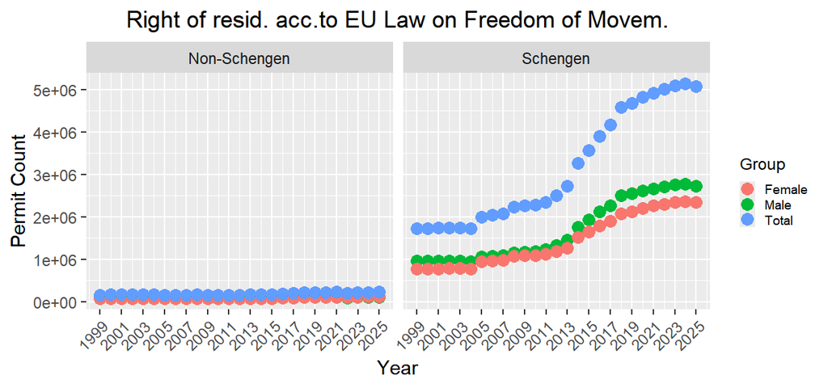

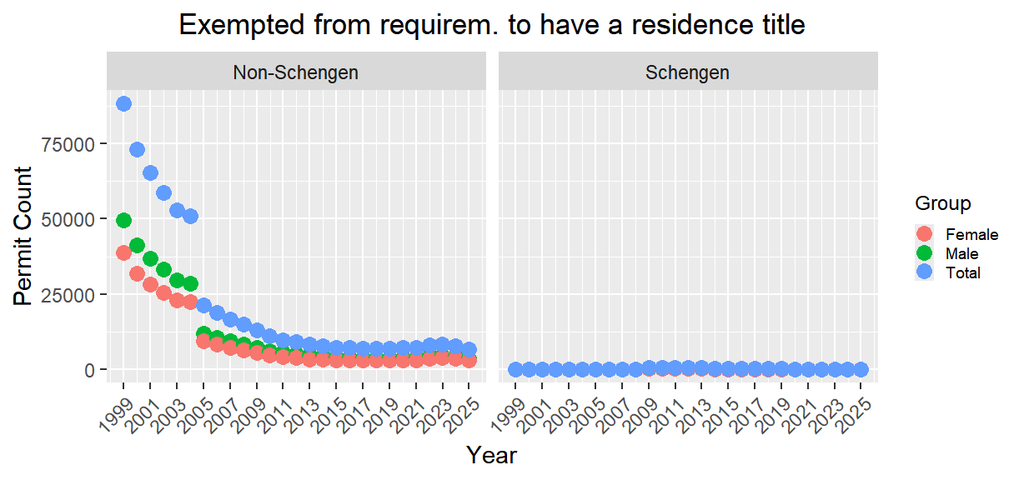

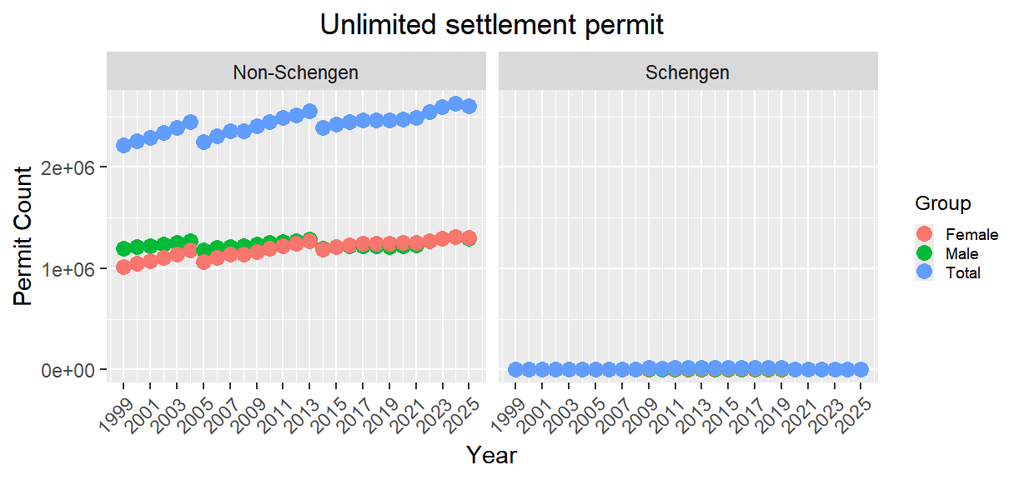

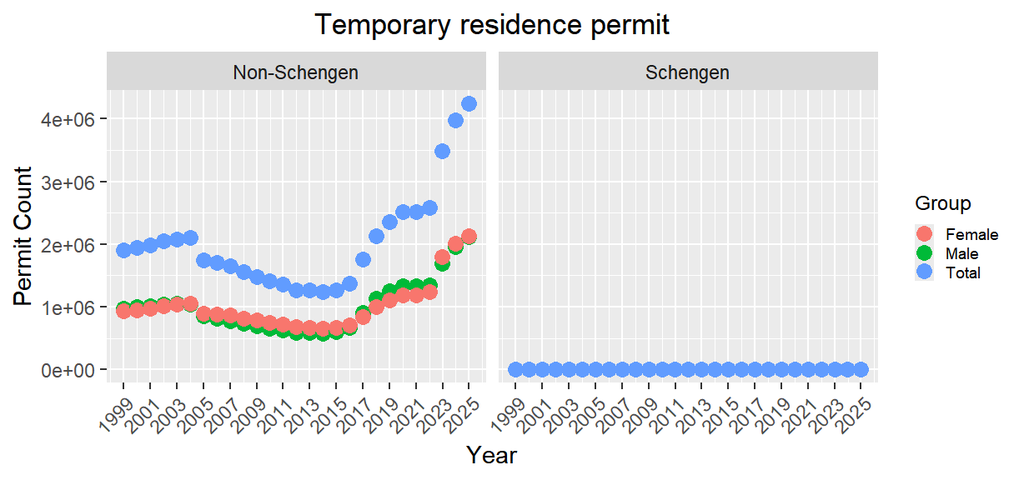

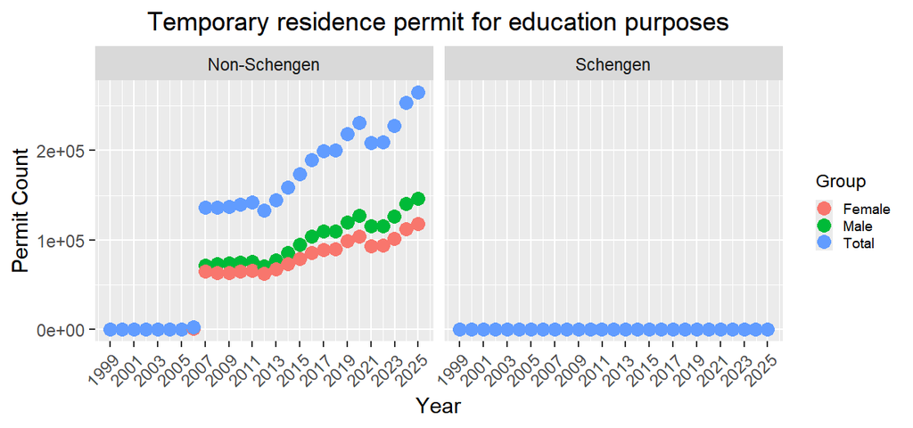

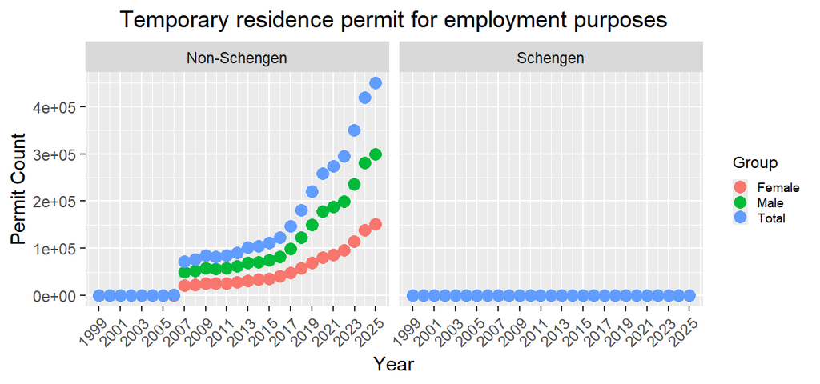

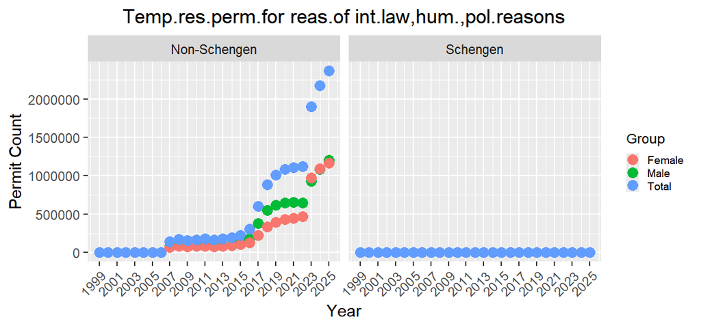

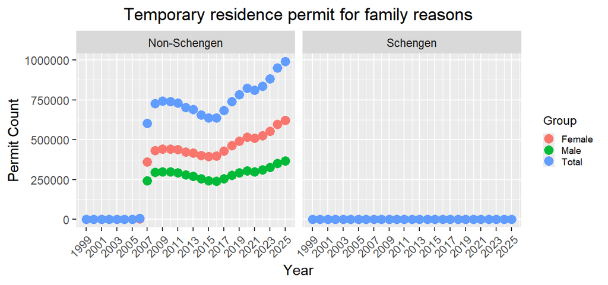

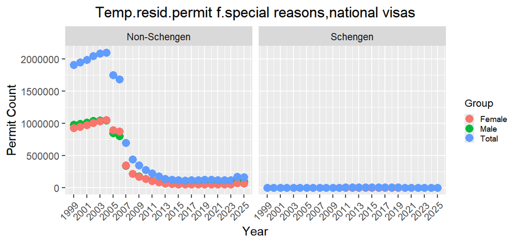

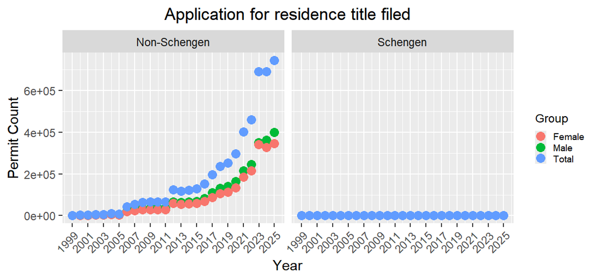

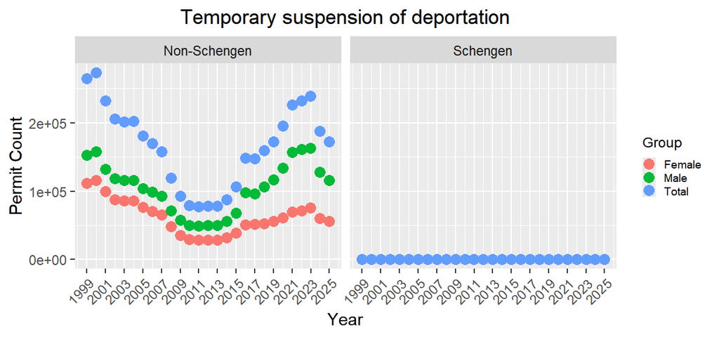

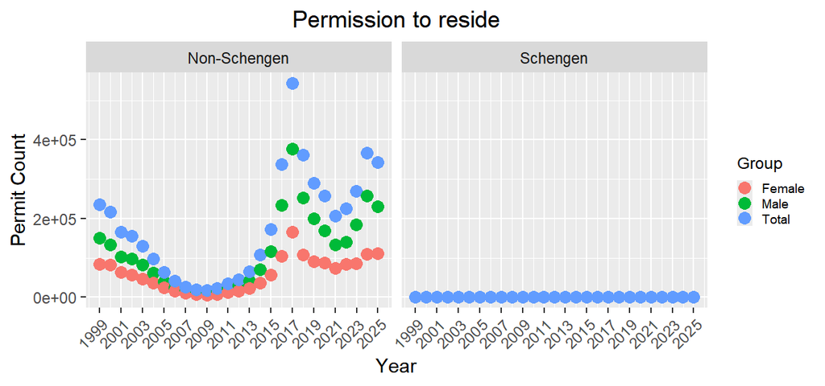

[2 more figures not shown]